# 100LC Frequency Distributions

Chris Bentz

May 15, 2019

This file illustrates how to use tokenized and linearized files of the 100LC texts to generate frequency lists of orthographic words and UTF-8 characters.

## Load libraries

```r
library(ggplot2)
library(gridExtra)
```

## Examples for Code Illustration

Specify paths to different tokenized and linearized text files for illustrating the workings and code of generating frequency lists.

```r
file.words <- "/home/chris/Data/100LC/Texts/Tokenized/Words/rus_pro_1.txt"
file.chars <- "/home/chris/Data/100LC/Texts/Tokenized/Characters/rus_pro_1.txt"
```

Read files.

```r
words <- scan(file.words, what = "char", sep = "\n", encoding = "UTF-8")
head(words)
```

```
## [1] "всеобщая"   "декларация" "прав"       "человека"   "принята"
## [6] "и"
```

```r
chars <- scan(file.chars, what = "char", sep = "\n", encoding = "UTF-8")
head(chars)
```

```
## [1] "в" "с" "е" "о" "б" "щ"
```

```r
freq.list <- table(words)
df <- as.data.frame(freq.list)
df <- df[with(df, order(-Freq)), ]
df$Rank <- 1:nrow(df)
df.words <- df
colnames(df.words)[1] <- c("Word")
head(df.words)
```

```
##       Word Freq Rank
## 192      и  116    1
## 36       в   51    2
## 293     на   40    3
## 477  право   36    4
## 227 каждый   32    5
## 201  имеет   30    6
```

Same for characters.

```r
freq.list <- table(chars)
df <- as.data.frame(freq.list)
df <- df[with(df, order(-Freq)), ]
df$Rank <- 1:nrow(df)
df.chars <- df
colnames(df.chars)[1] <- c("Char")
head(df.chars)
```

```
##    Char Freq Rank
## 22    о 1086    1
## 13    е  870    2
## 16    и  857    3
## 8     а  759    4
## 21    н  674    5
## 26    т  582    6
```

## ggplots of Frequency Distributions

### UTF-8 Characters

```r
figure.chars <- ggplot(df.chars, aes(x = Rank, y = Freq)) +
  geom_bar(stat = "identity", fill = "grey80") +
  geom_text(aes(label = Char), vjust = 0.5, hjust = 0.5, position = position_dodge(1),
            size = 5, colour = "black", angle = 45) +
  labs(x = "Rank", y = "Frequency", size = 2) +
  theme_bw() +
  scale_fill_manual(values = c("grey80")) +
  annotate("text", label = "Character Entropy = 4.5", x = 20, y = 750, color = "black", size = 5) +
  theme(axis.text.y = element_text(size = 10),
        axis.text.x = element_text(size = 10),
        axis.title.x = element_blank(),
        axis.title.y = element_text(size = 12),
        legend.position = "none")
```

### Orthographic Words

```r
figure.words <- ggplot(df.words, aes(x = Rank, y = Freq)) +
  geom_bar(stat = "identity", fill = "grey80") +
  geom_text(aes(label = Word), vjust = 0, hjust = 0, position = position_dodge(1),
            size = 4, colour = "black", angle = 45) +
  labs(x = "Rank", y = "Frequency", size = 2) +
  scale_x_continuous(limits = c(0, 40)) +
  scale_y_continuous(limits = c(0, 140)) +
  theme_bw() +
  annotate("text", label = "Word Entropy = 8.4", x = 20, y = 100, color = "black", size = 5) +
  scale_fill_manual(values = c("grey80")) +
  theme(axis.text.y = element_text(size = 10),
        axis.text.x = element_text(size = 10),
        axis.title.y = element_text(size = 12),
        legend.position = "none")
```

Arrange figures together.

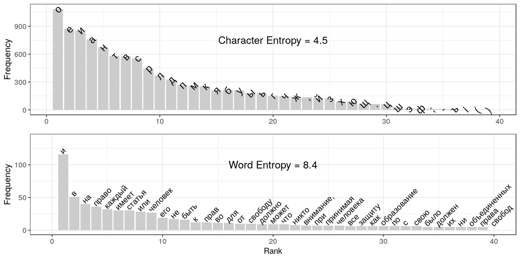

```r
fig.Dists <- grid.arrange(figure.chars, figure.words, ncol = 1)
```

```r
ggsave("Figures/figure_Dists.pdf", fig.Dists , dpi = 300, scale = 1, device = cairo_pdf)
```

## Application

### Frquency lists for characters

Read all paths to tokenized files in a given folder.

```r
files <- list.files(path = "/home/chris/Data/100LC/Texts/Tokenized/Characters", full.names = T)
head(files)
```

```
## [1] "/home/chris/Data/100LC/Texts/Tokenized/Characters/abk_pro_1.txt"
## [2] "/home/chris/Data/100LC/Texts/Tokenized/Characters/aey_nfi_1.txt"
## [3] "/home/chris/Data/100LC/Texts/Tokenized/Characters/amp_nfi_1.txt"
## [4] "/home/chris/Data/100LC/Texts/Tokenized/Characters/ape_nfi_1.txt"
## [5] "/home/chris/Data/100LC/Texts/Tokenized/Characters/apu_nfi_1.txt"
## [6] "/home/chris/Data/100LC/Texts/Tokenized/Characters/arn_nfi_1.txt"
```

Loop over all file paths to run the processing steps outlined above for each tokenized text file. Then safe the frequency lists in FreqLists/Characters as a .csv file, i.e. comma separated values.

```r
# ptime <- proc.time() # get system time before starting process
# for (file in files) {
#   chars <- scan(file, what = "char", sep = "\n", encoding = "UTF-8")
#   freq.list <- table(chars)
#   df <- as.data.frame(freq.list)
#   df <- df[with(df, order(-Freq)), ]
#   df$Rank <- 1:nrow(df)
#   colnames(df)[1] <- c("Char")
#   # write character frequency distributions to file
#   out.file.chars <- as.character(paste("/home/chris/Data/100LC/Texts/FreqLists/Characters/", basename(file), sep = ""))
#   write.csv(df, file = out.file.chars, row.names = F)
# }
# proc.time() - ptime # show time elapsed while processing
```

### Frequency lists for orthographic words

Read all paths to tokenized files in a given folder.

```r
files <- list.files(path = "/home/chris/Data/100LC/Texts/Tokenized/Words", full.names = T)
head(files)
```

```
## [1] "/home/chris/Data/100LC/Texts/Tokenized/Words/abk_pro_1.txt"
## [2] "/home/chris/Data/100LC/Texts/Tokenized/Words/aey_nfi_1.txt"
## [3] "/home/chris/Data/100LC/Texts/Tokenized/Words/amp_nfi_1.txt"
## [4] "/home/chris/Data/100LC/Texts/Tokenized/Words/ape_nfi_1.txt"
## [5] "/home/chris/Data/100LC/Texts/Tokenized/Words/apu_nfi_1.txt"
## [6] "/home/chris/Data/100LC/Texts/Tokenized/Words/arn_nfi_1.txt"
```

Loop over all file paths to run the processing steps outlined above for each tokenized text file. Then safe the frequency lists in FreqLists/Words as a .csv file, i.e. comma separated values.

```r
# ptime <- proc.time() # get system time before starting process
# for (file in files) {
#   words <- scan(file, what = "char", sep = "\n", encoding = "UTF-8")
#   freq.list <- table(words)
#   df <- as.data.frame(freq.list)
#   df <- df[with(df, order(-Freq)), ]
#   df$Rank <- 1:nrow(df)
#   colnames(df)[1] <- c("Word")
#   # write word frequency distributions to file
#   out.file.words <- as.character(paste("/home/chris/Data/100LC/Texts/FreqLists/Words/", basename(file), sep = ""))
#   write.csv(df, file = out.file.words, row.names = F)
# }
# proc.time() - ptime # show time elapsed while processing
```